# Reproducing JCI Paper

Rohit Satyam

rohit.satyam@kaust.edu.sa

May 06, 2024

# Contents

## 0.1 Bulk RNASeq Data analysis

```r
library(dplyr)
library(DESeq2)
library(NOISeq)
```

```r
setwd('~/data/coursework2024/week1/jcpaper/results')
file_paths <- list.files(path = ".",pattern = "_ReadsPerGene.out.tab")

# Initialize an empty list to store the data
files<-t(plyr::ldply(lapply(file_paths, function(x){
  read.table(x, skip=4)[,3]
})))

colnames(files) <- gsub("_ReadsPerGene.out.tab","",file_paths)
rownames(files) <- read.table(file_paths[1], skip=4)[,1]

## reading metadata
meta <- read.csv("SraRunTable.txt", header = T)
meta <- meta[,c(1,14)]
meta$disease_state <- mgsub::mgsub(meta$disease_state,c("Covid19: Acute infection","Covid19: Recovery 3Mo","Covid19: Recovery 6Mo"), c("Covid19AI","Covid19_3Mo","Covid19_6Mo"))
```

For making NOIseq ExpressionSet object, one can use the code given below to get the coordinates and GC% but since different database have different chromosome indexing (0-based or 1-based) this might not be ideal.

```r
## Using BioMart
library(biomaRt)
ensembl <- useEnsembl(biomart = "genes", dataset = "hsapiens_gene_ensembl")

#View(listAttributes(ensembl))
## Get the coordinates of genes to get length and GC content
attributes <- c("ensembl_gene_id", "chromosome_name", "start_position","end_position","percentage_gene_gc_content")
gene_info <- getBM(attributes = attributes,
                   filters = "ensembl_gene_id",
                   values = GeneStructureTools::removeVersion(rownames(files)[1:4]),
                   mart = ensembl)
```

Let’s try to procure the same information using our own GTF and FASTA file that were used for mapping the reads. This will enable us to use this code for any other non-model organism for which such information can not be obtained from BioMart.

```r
library(GenomicRanges)
library(rtracklayer)
library(Rsamtools)

# Load GTF file
GTFfile <- "../../resource/gencode.v45.primary_assembly.annotation.gtf"
GTF <- import.gff(GTFfile, format="gtf", genome="GRCh38", feature.type="gene")

# Reduce to merge overlapping features and simplify data structure
gene_ids <- mcols(GTF)$gene_id
gene_biotypes <- mcols(GTF)$gene_type

## reading the FASTA reference
FASTAfile = "../../resource/GRCh38.primary_assembly.genome.fa"
FASTA <- FaFile(FASTAfile)
seqs <- getSeq(FASTA, GTF)  # Use original GTF ranges to ensure correct sequence retrieval
gc_counts <- letterFrequency(seqs, letters = c("G", "C"), as.prob = FALSE)
lengths <- width(GTF)
gc_content <- rowSums(gc_counts) / lengths

# Extract necessary information (gene ID and gene biotype)
gene_info <- data.frame(
  gene_id = gene_ids,
  gene_biotype = gene_biotypes,
  gc=gc_content,
  length=lengths,starts=start(GTF),ends=end(GTF),
  chr=seqnames(GTF),stringsAsFactors = FALSE)
saveRDS(gene_info, "gene_info.rds")
```

Now, once we have all the attributes of all the genes, let’s compare the if the order of the genes in `gene_info` is same as the counts files we read.

```r
table(rownames(files)==gene_info$gene_id)
rownames(meta)<-meta$Run
meta <- meta[colnames(files),]
rownames(gene_info)<-gene_info$gene_id
## making expressionSet object to run noiseq functions
data_NOISEQ <- readData(data = files,
                        length=setNames(gene_info$length, gene_info$gene_id),
                        gc=setNames(gene_info$gc, gene_info$gene_id),
                        biotype=setNames(gene_info$gene_biotype, gene_info$gene_id),
                        chromosome = gene_info[,c("chr","starts","ends")],
                        factors = meta)

save(data_NOISEQ,files,gene_info,file="GSE198256_step1.Rda")
```

```r
## Loading all the
load("GSE198256_step1.Rda")
myexplodata <- dat(data_NOISEQ, type = "biodetection")
```

```
## Biotypes detection is to be computed for:
##  [1] "SRR18280823" "SRR18280824" "SRR18280825" "SRR18280826" "SRR18280827"
##  [6] "SRR18280828" "SRR18280829" "SRR18280830" "SRR18280831" "SRR18280832"
## [11] "SRR18280833" "SRR18280834" "SRR18280835" "SRR18280836" "SRR18280837"
## [16] "SRR18280838" "SRR18280839" "SRR18280840" "SRR18280841" "SRR18280842"
## [21] "SRR18280843" "SRR18280844" "SRR18280845" "SRR18280846" "SRR18280847"
## [26] "SRR18280848" "SRR18280849" "SRR18280850" "SRR18280851" "SRR18280852"
## [31] "SRR18280853" "SRR18280854" "SRR18280855" "SRR18280856"
```

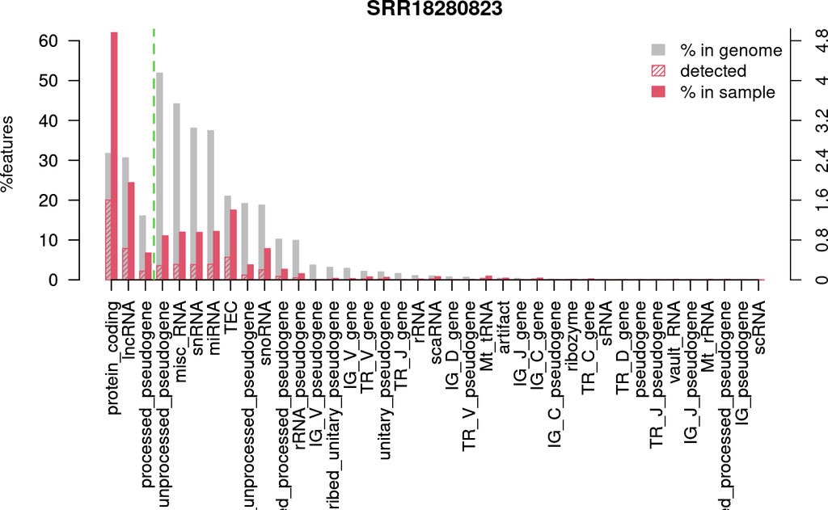

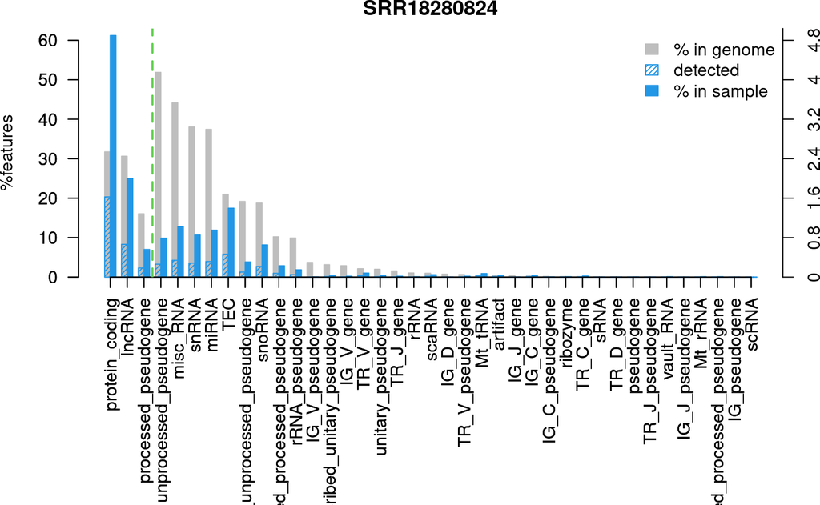

```r
explo.plot(myexplodata, plottype = "persample")
```

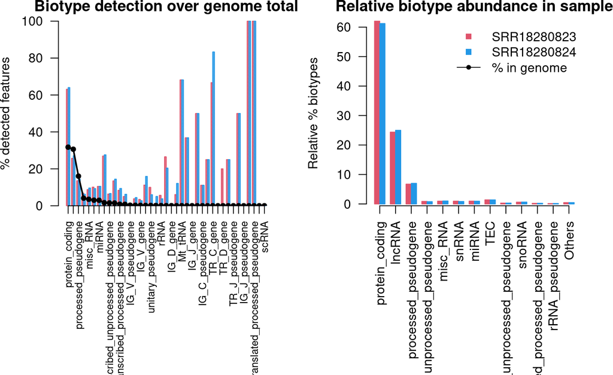

```
## [1] "Percentage of protein_coding biotype in each sample:"
## SRR18280823 SRR18280824
##     62.0294     61.2277
## [1] "Confidence interval at 95% for the difference of percentages: SRR18280823 - SRR18280824"
## [1] 0.2641 1.3393
## [1] "The percentage of this biotype is significantly DIFFERENT for these two samples (p-value = 0.003436 )."
```

```r
par(mfrow = c(1, 2))
explo.plot(myexplodata, samples = c(1, 2), toplot = "protein_coding", plottype = "comparison")
```

```r
mycountsbio = dat(data_NOISEQ, factor = NULL, type = "countsbio")
```

```
## [1] "Warning: 24938 features with 0 counts in all samples are to be removed for this analysis."
## [1] "Count distributions are to be computed for:"
##  [1] "SRR18280823" "SRR18280824" "SRR18280825" "SRR18280826" "SRR18280827"
##  [6] "SRR18280828" "SRR18280829" "SRR18280830" "SRR18280831" "SRR18280832"
## [11] "SRR18280833" "SRR18280834" "SRR18280835" "SRR18280836" "SRR18280837"
## [16] "SRR18280838" "SRR18280839" "SRR18280840" "SRR18280841" "SRR18280842"
## [21] "SRR18280843" "SRR18280844" "SRR18280845" "SRR18280846" "SRR18280847"
## [26] "SRR18280848" "SRR18280849" "SRR18280850" "SRR18280851" "SRR18280852"
## [31] "SRR18280853" "SRR18280854" "SRR18280855" "SRR18280856"
```

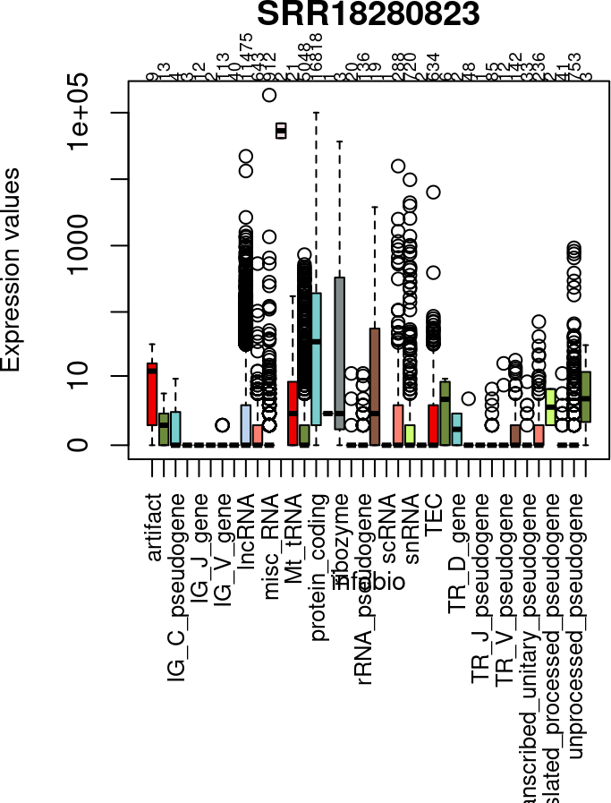

```r
explo.plot(mycountsbio, toplot = 1, samples = 1, plottype = "boxplot")
```

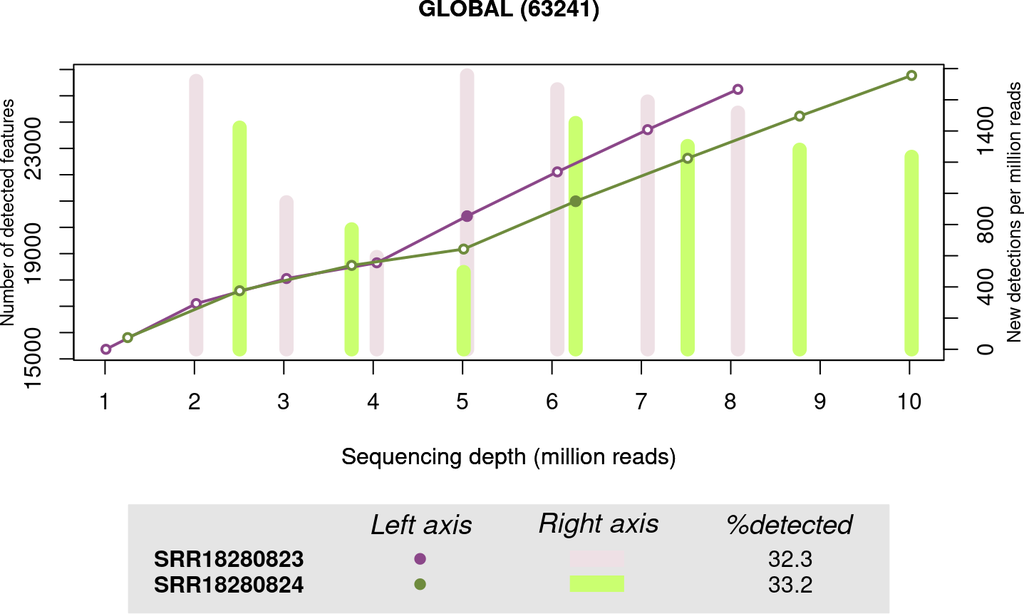

```r
mysaturation = dat(data_NOISEQ, k = 0, ndepth = 7, type = "saturation")
explo.plot(mysaturation, toplot = 1, samples = 1:2, yleftlim = NULL, yrightlim = NULL)
```

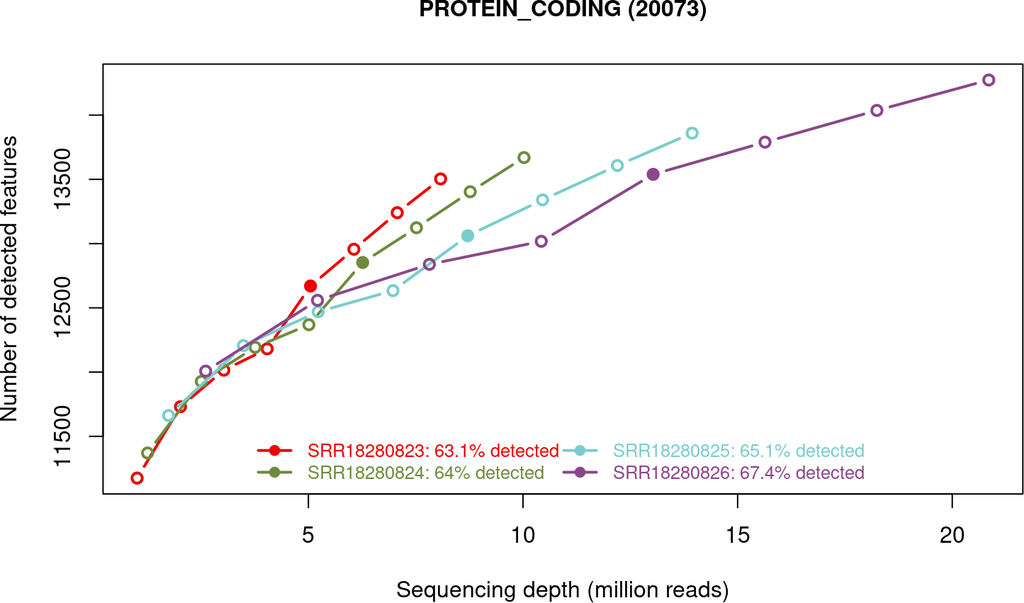

```r
explo.plot(mysaturation, toplot = "protein_coding", samples = 1:4)
```

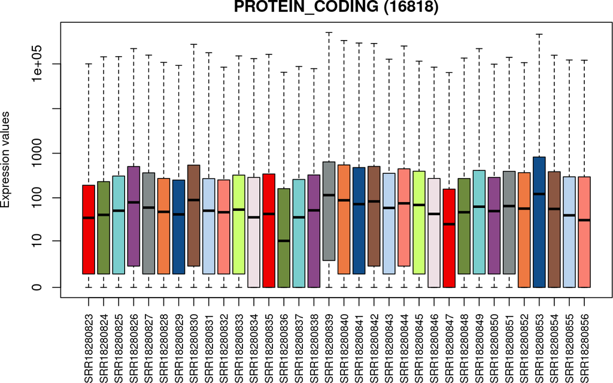

```r
explo.plot(mycountsbio, toplot = "protein_coding", samples = NULL, plottype = "boxplot")
```

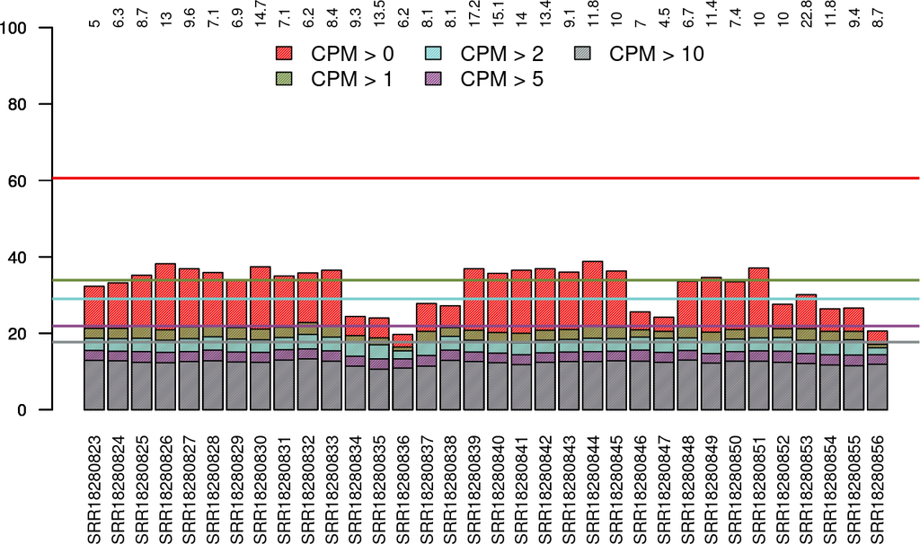

```r
explo.plot(mycountsbio, toplot = 1, samples = NULL, plottype = "barplot")
```

```r
mylengthbias = dat(data_NOISEQ, factor = "disease_state", type = "lengthbias")
```

```
## [1] "Warning: 24938 features with 0 counts in all samples are to be removed for this analysis."
## [1] "Length bias detection information is to be computed for:"
## [1] "Covid19_3Mo" "Covid19_6Mo" "Covid19AI"   "Healthy"
## [1] "Covid19_3Mo"
##
## Call:
## lm(formula = datos[, i] ~ bx)
##
## Residuals:
##     Min      1Q  Median      3Q     Max
## -9.4655 -0.8969 -0.1639  0.6966 15.5627
##
## Coefficients: (6 not defined because of singularities)
##               Estimate Std. Error t value Pr(>|t|)
## (Intercept)      7.848      3.111   2.523  0.01254 *
## bx1             -7.831      3.138  -2.495  0.01351 *
## bx2              4.219      3.330   1.267  0.20683
## bx3             14.568      3.579   4.070 7.12e-05 ***
## bx4             16.982      3.685   4.608 7.82e-06 ***
## bx5             24.332      3.995   6.091 7.01e-09 ***
## bx6             27.949      4.451   6.279 2.63e-09 ***
## bx7             35.840      5.288   6.778 1.81e-10 ***
## bx8             20.344      7.503   2.712  0.00737 **
## bx9             17.703     15.931   1.111  0.26799
## bx10            78.560     71.389   1.100  0.27265
## bx11          -595.484    739.037  -0.806  0.42148
## bx12          9754.187  11670.338   0.836  0.40441
## bx13        -82857.144  99360.674  -0.834  0.40548
## bx14        131334.042 157473.054   0.834  0.40542
## bx15         -2736.533   3332.830  -0.821  0.41272
## bx16                NA         NA      NA       NA
## bx17                NA         NA      NA       NA
## bx18                NA         NA      NA       NA
## bx19             8.715      4.831   1.804  0.07299 .
## bx20                NA         NA      NA       NA
## bx21                NA         NA      NA       NA
## bx22                NA         NA      NA       NA
## ---
## Signif. codes:  0 '***' 0.001 '**' 0.01 '*' 0.05 '.' 0.1 ' ' 1
##
```

[output cut: 111 more lines]

```
## bx14         2.044e+05  1.551e+05   1.317  0.18944
## bx15        -4.287e+03  3.284e+03  -1.305  0.19345
## bx16                NA         NA      NA       NA
## bx17                NA         NA      NA       NA
## bx18                NA         NA      NA       NA
## bx19         8.351e+00  4.760e+00   1.754  0.08112 .
## bx20                NA         NA      NA       NA
## bx21                NA         NA      NA       NA
## bx22                NA         NA      NA       NA
## ---
## Signif. codes:  0 '***' 0.001 '**' 0.01 '*' 0.05 '.' 0.1 ' ' 1
##
## Residual standard error: 3.065 on 174 degrees of freedom
## Multiple R-squared:  0.9461, Adjusted R-squared:  0.9411
## F-statistic: 190.8 on 16 and 174 DF,  p-value: < 2.2e-16
```

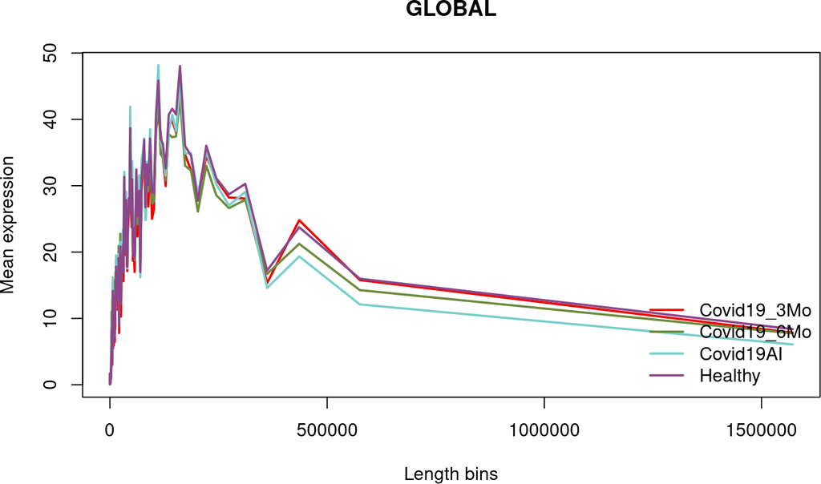

```r
explo.plot(mylengthbias, samples = NULL, toplot = "global")
```

```r
myGCbias = dat(data_NOISEQ, factor = "disease_state", type = "GCbias")
```

```
## [1] "Warning: 24938 features with 0 counts in all samples are to be removed for this analysis."
## [1] "GC content bias detection is to be computed for:"
## [1] "Covid19_3Mo" "Covid19_6Mo" "Covid19AI"   "Healthy"
## [1] "Covid19_3Mo"
##
## Call:
## lm(formula = datos[, i] ~ bx)
##
## Residuals:
##    Min     1Q Median     3Q    Max
## -6.338 -1.925 -0.327  1.492  8.446
##
## Coefficients: (3 not defined because of singularities)
##             Estimate Std. Error t value Pr(>|t|)
## (Intercept)   0.8728     2.9122   0.300 0.764766
## bx1          -0.4246     4.1185  -0.103 0.917999
## bx2               NA         NA      NA       NA
## bx3               NA         NA      NA       NA
## bx4          45.8334   166.3560   0.276 0.783254
## bx5          -4.9602    17.1948  -0.288 0.773335
## bx6           0.4966     5.3013   0.094 0.925472
## bx7          23.2015     3.6153   6.418 1.31e-09 ***
## bx8          15.8894     3.2878   4.833 2.98e-06 ***
## bx9          11.7087     3.2223   3.634 0.000369 ***
## bx10         12.2996     3.2228   3.816 0.000189 ***
## bx11          5.2713     3.2583   1.618 0.107549
## bx12          8.1101     3.3074   2.452 0.015206 *
## bx13          4.5686     3.3462   1.365 0.173950
## bx14          9.5218     3.4065   2.795 0.005781 **
## bx15          2.4138     3.5237   0.685 0.494257
## bx16          9.1736     3.7282   2.461 0.014864 *
## bx17          0.8047     4.0887   0.197 0.844201
## bx18          9.4458     4.8010   1.967 0.050745 .
## bx19         -0.3977     6.5520  -0.061 0.951672
## bx20          7.6692    33.1559   0.231 0.817352
## bx21        -46.8734   300.5608  -0.156 0.876254
## bx22              NA         NA      NA       NA
## ---
## Signif. codes:  0 '***' 0.001 '**' 0.01 '*' 0.05 '.' 0.1 ' ' 1
##
```

[output cut: 111 more lines]

```
## bx14          9.1275     3.2890   2.775  0.00613 **
## bx15          2.9866     3.4021   0.878  0.38125
## bx16          8.1541     3.5996   2.265  0.02475 *
## bx17          1.2585     3.9476   0.319  0.75027
## bx18          8.8529     4.6354   1.910  0.05783 .
## bx19         -0.3395     6.3260  -0.054  0.95726
## bx20          8.6621    32.0122   0.271  0.78703
## bx21        -61.6147   290.1931  -0.212  0.83211
## bx22              NA         NA      NA       NA
## ---
## Signif. codes:  0 '***' 0.001 '**' 0.01 '*' 0.05 '.' 0.1 ' ' 1
##
## Residual standard error: 2.812 on 171 degrees of freedom
## Multiple R-squared:  0.805,  Adjusted R-squared:  0.7833
## F-statistic: 37.14 on 19 and 171 DF,  p-value: < 2.2e-16
```

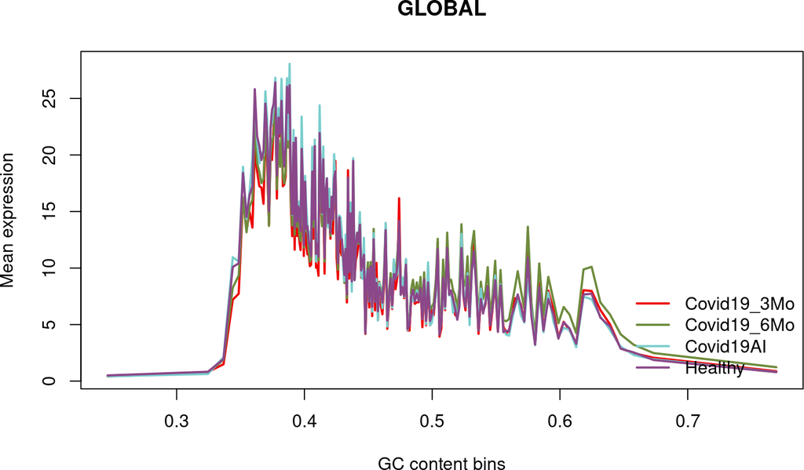

```r
explo.plot(myGCbias, samples = NULL, toplot = "global")
```

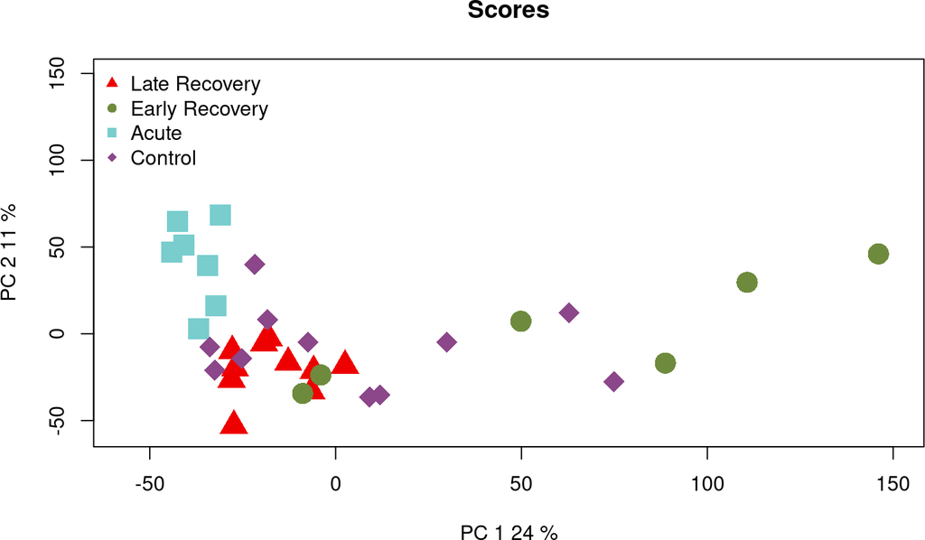

```r
#mycd = dat(data_NOISEQ, type = "cd", norm = FALSE, refColumn = 1)
#explo.plot(mycd,samples = 1:12)

myPCA = dat(data_NOISEQ, type = "PCA")
## To match paper's label
myPCA@dat$factors$disease_state <- mgsub::mgsub(myPCA@dat$factors$disease_state,unique(myPCA@dat$factors$disease_state),c("Late Recovery","Early Recovery","Acute","Control"))
explo.plot(myPCA, factor = "disease_state")
```

```r
## Since we have more than two condition, the linew below will throw an error
#QCreport(data_NOISEQ, samples = NULL, factor = "disease_state", norm = FALSE)
```

### 0.1.1 Normalization and differential expression with DESeq

NOISeq offers different flavors of normalization such as RPKM, UQ and TMM. The code to do this is given below.

```r
## Normalisation approached provided by NOISeq includes RPKM, Upper Quartile and TMM (Trimmed Mean of M)
myRPKM = rpkm(assayData(data_NOISEQ)$exprs, long = data_NOISEQ@featureData@data$Length, k = 0, lc = 1)
myUQUA = uqua(assayData(data_NOISEQ)$exprs, long = data_NOISEQ@featureData@data$Length, lc = 0.5, k = 0)
myTMM = tmm(assayData(data_NOISEQ)$exprs, long = 1000, lc = 0)
```

But since we wanna use DESeq2 we will use the raw counts and perform gene filtering before carrying out differential analysis.

```r
## Make DESeqDataSet object
GSE198256_DESeq2 <- DESeqDataSetFromMatrix(countData = data_NOISEQ@assayData$exprs,
                                           colData = data_NOISEQ@phenoData@data,
                                           design = ~ disease_state)
GSE198256_DESeq2$disease_state<-relevel(GSE198256_DESeq2$disease_state,ref = "Healthy")

# Filtering genes with low counts
dim(GSE198256_DESeq2)
```

```
## [1] 63241    34
```

```r
## Adding gene names and metadata
rowData(GSE198256_DESeq2) <- data_NOISEQ@featureData@data
## Adding Gene symbols
mcols(GSE198256_DESeq2)$names <- GTF$gene_name[match(GTF$gene_id,rownames(data_NOISEQ@featureData@data) )]

## Finding the smallest group size
smallestGroupSize <- min(table(GSE198256_DESeq2$disease_state))
smallestGroupSize
```

```
## [1] 6
```

```r
# remove genes that do not have counts >=10 in atleast 6 sample
keep <- rowSums(counts(GSE198256_DESeq2) >= 10) >= smallestGroupSize
GSE198256_DESeq2_F <- GSE198256_DESeq2[keep,] # 14,055 x 34
dim(GSE198256_DESeq2_F)
```

```
## [1] 15568    34
```

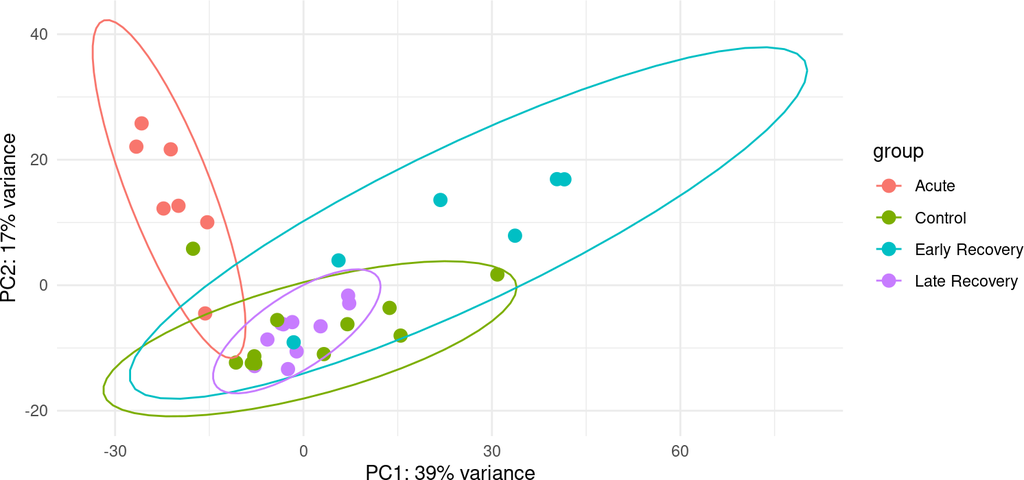

```r
GSE198256_DESeq2_F$labels <- as.character(GSE198256_DESeq2_F$disease_state)
GSE198256_DESeq2_F$labels <- mgsub::mgsub(GSE198256_DESeq2_F$labels,unique(GSE198256_DESeq2_F$labels),c("Late Recovery","Early Recovery","Acute","Control"))
## making PCA using VST normalised data
vsd <- vst(GSE198256_DESeq2_F, blind=TRUE,fitType = "parametric")
plotPCA(vsd, intgroup=c("labels"), returnData=FALSE)+ggplot2::theme_minimal()+
    ggplot2::stat_ellipse()
```

```r
## Differential expression analysis
GSE198256_DESeq2_F<- DESeq(GSE198256_DESeq2_F)

#results(dds, contrast=c("condition","treated","untreated"))
ctrl.vs.acute <- results(GSE198256_DESeq2_F, contrast=c("disease_state","Covid19AI","Healthy"))
ctrl.vs.early <- results(GSE198256_DESeq2_F, contrast=c("disease_state","Covid19_3Mo","Healthy"))
ctrl.vs.late <- results(GSE198256_DESeq2_F, contrast=c("disease_state","Covid19_6Mo","Healthy"))
```

#### 0.1.1.1 Q1. Do we use all the genes?

Filtering genes before performing differential expression analysis is a critical step in RNASeq pipeline due to following reasons:

- **Low Expression**: Genes that are expressed at very low levels across all samples often reflect background noise rather than true biological signals. These low counts can lead to high variability and unreliable statistical tests.
- **Increasing Statistical Power**: By removing genes that are unlikely to be informative (e.g., those with very low expression), you can reduce the multiple testing burden and increase the statistical power to detect true differences in the remaining genes.
- **Speeding Up Analysis**: Filtering out a significant number of genes from the analysis can dramatically decrease the computational time required for downstream statistical testing and analysis.
- **Resource Management**: This is particularly important when dealing with large datasets like TCGA Cancer dataset or limited computational resources.

#### 0.1.1.2 Q2. How do we select which ones?

There are several ways to skin a cat so you can choose one of the following criteria:

- **Expression Level**: Genes with average counts below a certain threshold across all samples are often filtered out (See below that we take expression value threshold as `10`).
- **Presence/Absence**: Genes need to be expressed in a minimum number of samples or sample groups (See below where we choose the minimum no. of sample based on the smallest subgroup).
- **Coefficient of Variation:** Genes with very high variability relative to their mean expression might be excluded. This method is less common but one can filter genes which vary greatly across say technical or biological replicates.

# 1 Understanding the DE results

# 2 plot MA

```r
resultsNames(GSE198256_DESeq2_F)
```

```
## [1] "Intercept"
## [2] "disease_state_Covid19_3Mo_vs_Healthy"
## [3] "disease_state_Covid19_6Mo_vs_Healthy"
## [4] "disease_state_Covid19AI_vs_Healthy"
```

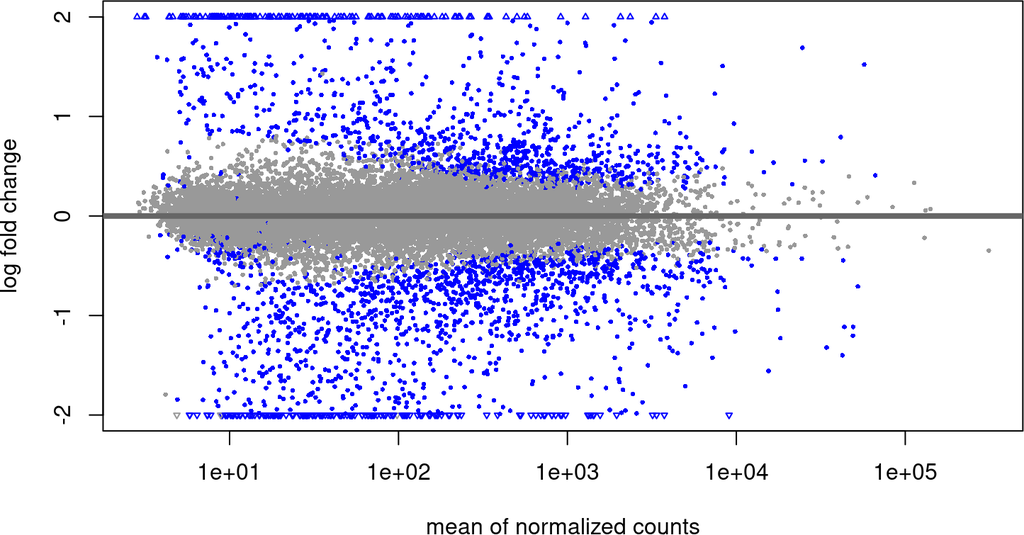

```r
ctrl.vs.acute <- lfcShrink(GSE198256_DESeq2_F, coef = 4)
ctrl.vs.early <- lfcShrink(GSE198256_DESeq2_F, coef=2)
ctrl.vs.late <- lfcShrink(GSE198256_DESeq2_F, coef=3)

## table(rownames(ctrl.vs.acute)==rownames(rowData(GSE198256_DESeq2_F)))
ctrl.vs.acute$symbol <- rowData(GSE198256_DESeq2_F)$names
ctrl.vs.early$symbol <- rowData(GSE198256_DESeq2_F)$names
ctrl.vs.late$symbol <- rowData(GSE198256_DESeq2_F)$names


plotMA(ctrl.vs.acute, ylim=c(-2,2))
```

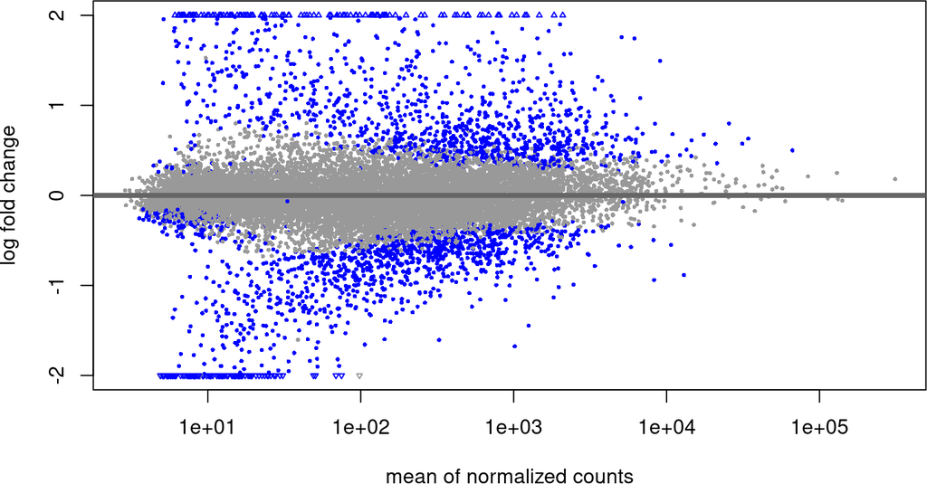

```r
plotMA(ctrl.vs.early, ylim=c(-2,2))
```

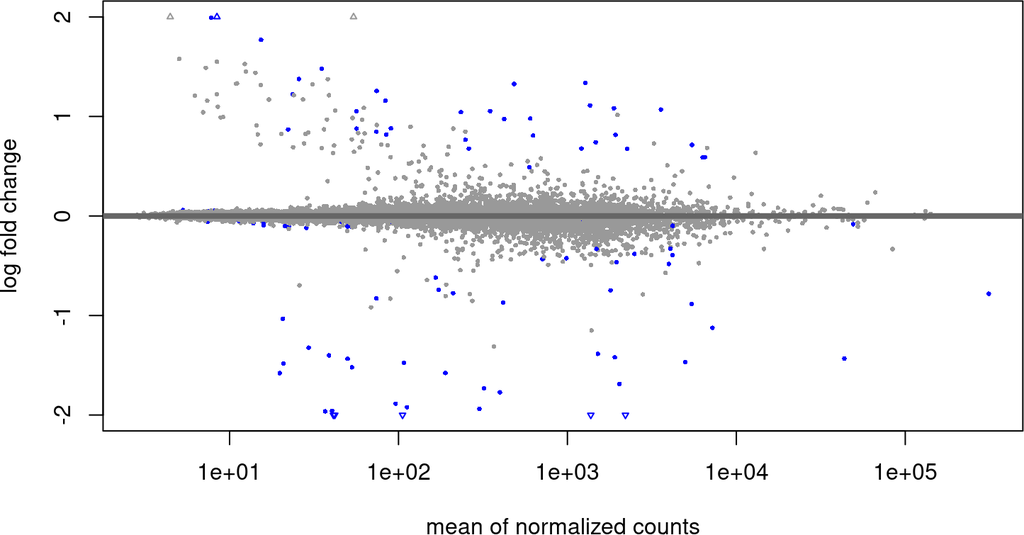

```r
plotMA(ctrl.vs.late, ylim=c(-2,2))
```

```r
## Filter DEGs
#filter DEGs: |FC| > 2 and FDR < 0.05 i.e. LFC value of 1
gtools::logratio2foldchange(1)
```

```
## [1] 2
```

```r
ctrl.vs.acute.sig <- subset(as.data.frame(ctrl.vs.acute) %>%tibble::rownames_to_column("Geneid"), padj <= 0.05 & abs(log2FoldChange)>1)
ctrl.vs.early.sig <- subset(as.data.frame(ctrl.vs.early)%>%tibble::rownames_to_column("Geneid"), padj <= 0.05 & abs(log2FoldChange)>1)
ctrl.vs.late.sig <- subset(as.data.frame(ctrl.vs.late)%>%tibble::rownames_to_column("Geneid"), padj <= 0.05 & abs(log2FoldChange)>1)

res <- list("Ctrl vs Acute"=ctrl.vs.acute.sig,
            "Ctrl vs Early Recov"=ctrl.vs.early.sig,
            "Ctrl vs Late Recov"=ctrl.vs.late.sig)
writexl::write_xlsx(res,"jci_DEGs.xlsx")
# Why to shrink: it looks at the largest fold changes that are not due
# to low counts and uses these to inform a prior distribution.
# So the large fold changes from genes with lots of statistical information are
# not shrunk, while the imprecise fold changes are shrunk. This allows you to
# compare all estimated LFC across experiments, for example, which is not really
# feasible without the use of a prior.
# Michael Love https://support.bioconductor.org/p/77461/
```

**Interpretation:** The MA plot provides a quick visual assessment of the differential expression analysis. It helps to identify genes that are significantly differentially expressed (blue points) and to see how the fold changes distribute across genes with different expression levels. The data points’ spread along the y-axis (M) often narrows as you move to the right along the x-axis (A) because the relative change in expression (fold change) is generally more stable for genes with higher expression levels, reflecting the decreased variance associated with more abundant transcripts.

As expected, we can see that there are very few DEGs when Late Recovery monocytes samples were compared to control samples

### 2.0.1 Comparison between *Brauns et. al.* and our analysis.

Severe COVID-19 significantly disrupts the myeloid immune cells during the infection, with effects lingering after recovery. The (Brauns et al. 2022) paper revealed that during the acute phase, patients with severe COVID-19 had monocytes with reduced cytokine production. Although the monocyte function mostly recovered after the illness, individuals who with Acute COVID showed heightened responses to certain immune triggers. Here we tried to reproduce their RNASeq data analysis in order to gauge to what extent we can reproduce the results. We use a slightly different pipeline and thresholds as tabulated below

**Difference in methodologies:**

Table 1: Differences between our RNASeq analysis pipeline and JCI paper’s.

[output not shown]

**Comparing the results**

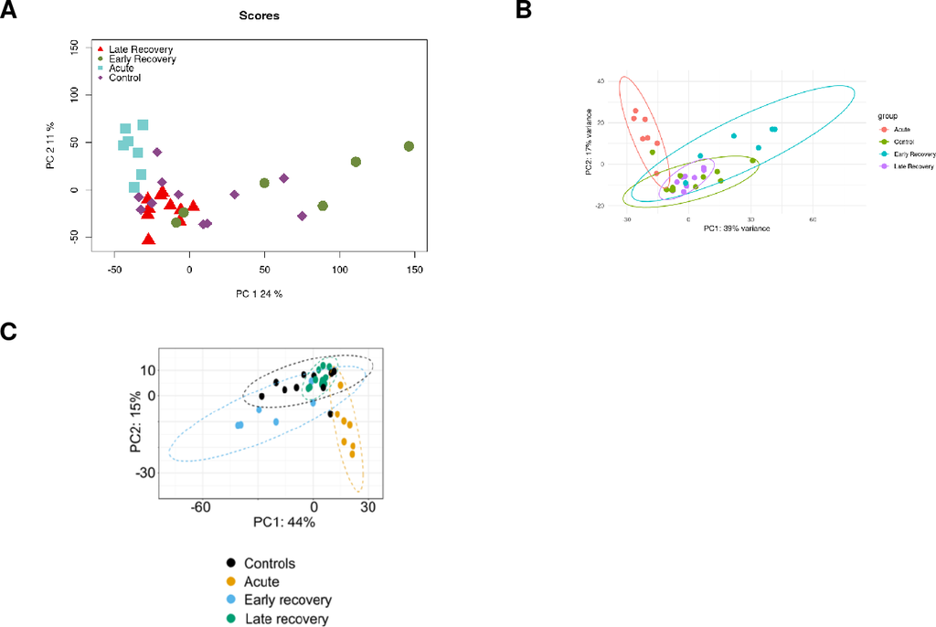

```r
library(png)
library(grid)
library(gridExtra)
img3 <-  rasterGrob(as.raster(readPNG("images/Screenshot from 2024-04-27 18-07-36.png")), interpolate = FALSE)
img1 <-  rasterGrob(as.raster(readPNG("images/PCA2.png")), interpolate = FALSE)
img2 <-  rasterGrob(as.raster(readPNG("images/PCA3.png")), interpolate = FALSE)
ggpubr::ggarrange(img1,img2,img3, ncol = 2, nrow = 2,labels = "AUTO")
```

The authors used DESeq2 to perform the differential expression analysis. So using DESeq2 and performed DGEA for three comparisons: acute infection (AI) vs healthy (H), and the two stages of recovery (3Mo and 6Mo) vs healthy. We kept the genes that passed the thresholds mentioned in the article, FDR < 0.05 and |FC| > 2 i.e LFC of 1.

```r
library(schoolmath)
ctrl.vs.acute.sig$status <- ifelse(is.negative(ctrl.vs.acute.sig$log2FoldChange),"down","up")
table(ctrl.vs.acute.sig$status)
```

```
##
## down   up
##  571  350
```

```r
ctrl.vs.early.sig$status <- ifelse(is.negative(ctrl.vs.early.sig$log2FoldChange),"down","up")
table(ctrl.vs.early.sig$status)
```

```
##
## down   up
##  317  378
```

```r
ctrl.vs.late.sig$status <- ifelse(is.negative(ctrl.vs.late.sig$log2FoldChange),"down","up")
table(ctrl.vs.late.sig$status)
```

```
##
## down   up
##   26   11
```

The patients with Acute COVID showed highest number of DEGs (`571 down-regulated and 350 up-regulated`) followed by Early Recovery patients (`317 down-regulated 378 up-regulated`). This was oppose to what paper observed i.e. more DEGs in Early recovery and less in Acute Infection patients. The Late recovery patients showed very few DEGs (`26 down 11 up`) which is in corcordance with the paper.

As authors reported, we also found down-regulation of genes related to key immune pathways, such as antigenic presentation, innate immune responses and MAPK and NF-κB signalling (JUNB, ATF3, NFkB2) in monocytes from patients suffering from Acute COVID-19. In addition, we also didn’t observe the upregulation of immunosuppressive genes such as ARG1, IL-10, or IDO1 in Acute Patients which is in concordance with what the paper has reported.

Like authors mentioned, for Ctrl vs Early recovery samples we also observed upregulation of genes encoding chemokines, along with important intracellular immunomodulatory proteins and transcription factors (PPARG, FOSL1, MAFB, MAFF, FOXO3) except ATF4.

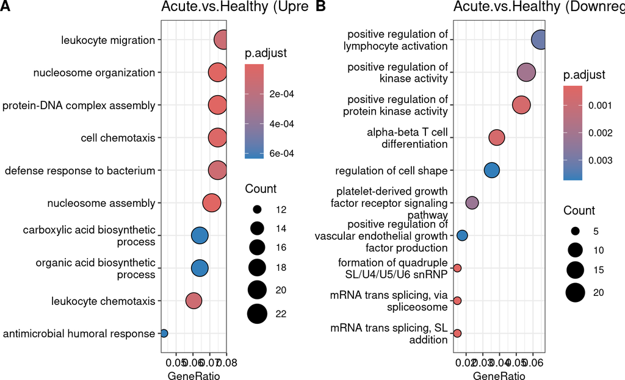

```r
library(clusterProfiler)
library(org.Hs.eg.db)
library(GeneStructureTools)
a <- enrichGO(gene = unique(removeVersion(ctrl.vs.acute.sig[ctrl.vs.acute.sig$status=="up",]$Geneid)),
OrgDb = org.Hs.eg.db, keyType = "ENSEMBL",
ont = "BP",
pAdjustMethod = "BH",
pvalueCutoff = 0.05,
qvalueCutoff = 0.1,
readable = TRUE)

b <- enrichGO(gene = unique(removeVersion(ctrl.vs.acute.sig[ctrl.vs.acute.sig$status=="down",]$Geneid)),
OrgDb = org.Hs.eg.db, keyType = "ENSEMBL",
ont = "BP",
pAdjustMethod = "BH",
pvalueCutoff = 0.05,
qvalueCutoff = 0.1,
readable = TRUE)

#dotplot
plt1 <- dotplot(a, showCategory = 10,
font.size = 10,
title = "Acute.vs.Healthy (Upreg)")

plt2 <- dotplot(b, showCategory = 10,
font.size = 10,
title = "Acute.vs.Healthy (Downreg)")
ggpubr::ggarrange(plt1,plt2,labels = "AUTO")
```

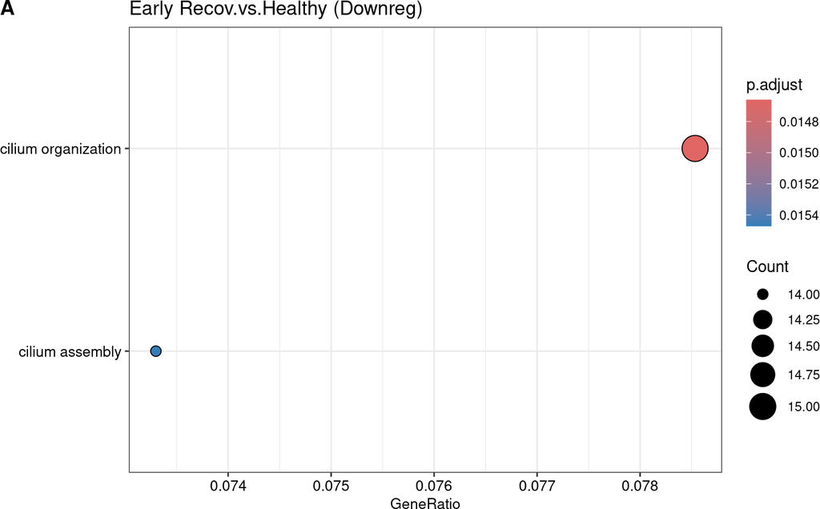

```r
a <- enrichGO(gene = unique(removeVersion(ctrl.vs.early.sig[ctrl.vs.early.sig$status=="up",]$Geneid)),
OrgDb = org.Hs.eg.db, keyType = "ENSEMBL",
ont = "BP",
pAdjustMethod = "BH",
pvalueCutoff = 0.05,
qvalueCutoff = 0.1,
readable = TRUE)

b <- enrichGO(gene = unique(removeVersion(ctrl.vs.early.sig[ctrl.vs.early.sig$status=="down",]$Geneid)),
OrgDb = org.Hs.eg.db, keyType = "ENSEMBL",
ont = "BP",
pAdjustMethod = "BH",
pvalueCutoff = 0.05,
qvalueCutoff = 0.1,
readable = TRUE)

#dotplot
# plt1 <- dotplot(a, showCategory = 10,
# font.size = 10,
# title = "Early Recov.vs.Healthy (Upreg)")
## No-enrichment was observed for upregulated genes
plt2 <- dotplot(b, showCategory = 10,
font.size = 10,
title = "Early Recov.vs.Healthy (Downreg)")
ggpubr::ggarrange(plt2,labels = "AUTO")
```

### 2.0.2 GSEA

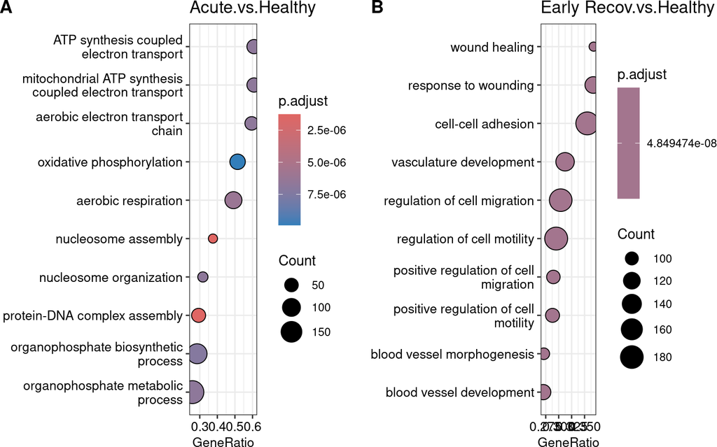

```r
rank.wt <- -log10(ctrl.vs.acute$pvalue) * sign(ctrl.vs.acute$log2FoldChange)
names(rank.wt) <- removeVersion(rownames(ctrl.vs.acute))
rank.wt <- sort(rank.wt,decreasing = T)

a <- gseGO(geneList=,rank.wt,
ont ="BP",
keyType = "ENSEMBL",
minGSSize = 3,
maxGSSize = 800,
pvalueCutoff = 0.05,
verbose = TRUE,
OrgDb = org.Hs.eg.db,
pAdjustMethod = "BH")

plt1 <- dotplot(a, showCategory = 10,
        font.size = 10,
        title = "Acute.vs.Healthy")

rank.wt <- -log10(ctrl.vs.early$pvalue) * sign(ctrl.vs.early$log2FoldChange)
names(rank.wt) <- removeVersion(rownames(ctrl.vs.early))
rank.wt <- sort(rank.wt,decreasing = T)

b <- gseGO(geneList=,rank.wt,
ont ="BP",
keyType = "ENSEMBL",
minGSSize = 3,
maxGSSize = 800,
pvalueCutoff = 0.05,
verbose = TRUE,
OrgDb = org.Hs.eg.db,
pAdjustMethod = "BH")

plt2 <- dotplot(b, showCategory = 10,
        font.size = 10,
        title = "Early Recov.vs.Healthy")

ggpubr::ggarrange(plt1,plt2,labels = "AUTO")
```

Results from paper are shown below:

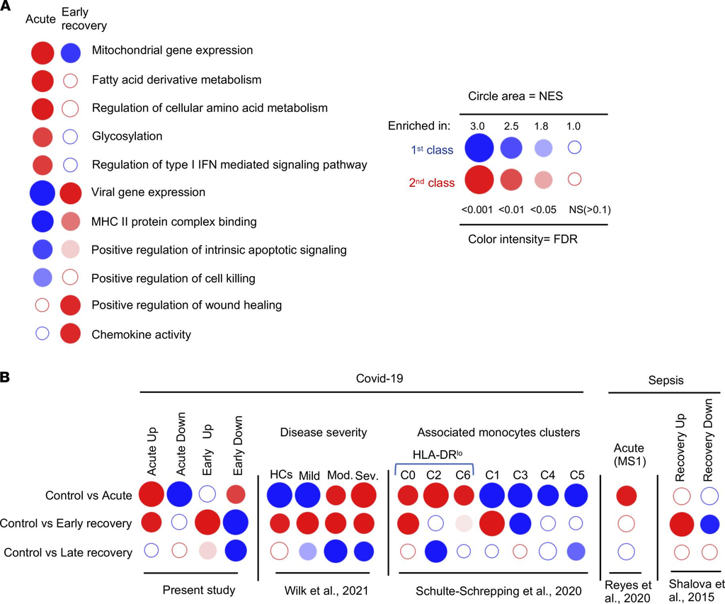

Brauns, Elisa, Abdulkader Azouz, David Grimaldi, Hanxi Xiao, Séverine Thomas, Muriel Nguyen, Véronique Olislagers, et al. 2022. “Functional Reprogramming of Monocytes in Patients with Acute and Convalescent Severe COVID-19.” *JCI Insight* 7 (9). https://doi.org/10.1172/jci.insight.154183.